# DATA SCIENCE ARCHITECTURE AI and ML Part 3

```r
# Identify predictors and response
y <- "response"
x <- setdiff(names(train), y)

# For binary classification, response should be a factor
train[, y] <- as.factor(train[, y])
test[, y] <- as.factor(test[, y])



# Run AutoML for 15 base models
aml <- h2o.automl(x = x, y = y,
                  training_frame = train,
                  validation_frame = test,
                  max_models = 15,
                  max_runtime_secs = 300,
                  seed = 19,
                  exploitation_ratio = .5,
                  preprocessing = "target_encoding",
                  keep_cross_validation_predictions = TRUE,
                  keep_cross_validation_fold_assignment = TRUE,
                  keep_cross_validation_models = TRUE,
                  include_algos = c("GLM",
                                    "GBM",
                                    "DeepLearning",
                                    "DRF",
                                    "StackedEnsemble",
                                    "XGBoost"
                                    )
                  )
```

[output not shown]

```r
pred <- h2o.predict(aml, test)
```

```
##   |                                                                              |                                                                      |   0%  |                                                                              |=========================================================…
```

```r
pred
```

```
##   predict        p0        p1
## 1       0 0.7585546 0.2414454
## 2       0 0.7111611 0.2888389
## 3       1 0.5267868 0.4732132
## 4       1 0.3790432 0.6209568
## 5       0 0.7194582 0.2805418
## 6       1 0.2587402 0.7412598
##
## [5000 rows x 3 columns]
```

```r
model.param <- automlModelParam(aml@leader)
model.param
```

```
##                         model_id ntrees max_depth min_rows sample_rate
## 1 GBM_1_AutoML_15_20240718_85902     49        15      100         0.8
##   col_sample_rate_per_tree min_split_improvement seed distribution
## 1                      0.8                  <NA>   20    bernoulli
##   stopping_metric stopping_tolerance
## 1         logloss               0.01
```

```r
perf <- h2o.performance(aml@leader, xval = TRUE)
performance(perf)
```

```
##                aucpr                   f2                  mcc
##            0.7998535            0.8610027            0.4138773
##                kappa                  auc mean_per_class_error
##            0.4112618            0.7823365            0.3322160
```

```r
# View the AutoML Leaderboard
lb <- aml@leaderboard
print(lb, n = nrow(lb))
```

```
##                                                model_id       auc   logloss
## 1                        GBM_1_AutoML_15_20240718_85902 0.7823365 0.5576492
## 2                        GBM_5_AutoML_15_20240718_85902 0.7799989 0.5609855
## 3           GBM_grid_1_AutoML_15_20240718_85902_model_2 0.7792186 0.5621636
## 4           GBM_grid_1_AutoML_15_20240718_85902_model_1 0.7781019 0.5620892
## 5                        GBM_2_AutoML_15_20240718_85902 0.7759464 0.5636773
## 6                        GBM_3_AutoML_15_20240718_85902 0.7751384 0.5646148
## 7           GBM_grid_1_AutoML_15_20240718_85902_model_3 0.7749474 0.5657197
## 8                        GBM_4_AutoML_15_20240718_85902 0.7742530 0.5668031
## 9                        DRF_1_AutoML_15_20240718_85902 0.7657954 0.5803946
## 10                       XRT_1_AutoML_15_20240718_85902 0.7600573 0.5852427
## 11 DeepLearning_grid_1_AutoML_15_20240718_85902_model_1 0.7333474 0.6288743
## 12              DeepLearning_1_AutoML_15_20240718_85902 0.7206165 0.6179016
## 13                       GLM_1_AutoML_15_20240718_85902 0.6826525 0.6385202
##        aucpr mean_per_class_error      rmse       mse
## 1  0.7998535            0.3322160 0.4352855 0.1894734
## 2  0.7974935            0.3177555 0.4365882 0.1906092
## 3  0.7968146            0.3163956 0.4370600 0.1910214
## 4  0.7950570            0.3418061 0.4374305 0.1913454
## 5  0.7969840            0.3403384 0.4383222 0.1921264
## 6  0.7959063            0.3451342 0.4387778 0.1925259
## 7  0.7907964            0.3271236 0.4388591 0.1925973
## 8  0.7923470            0.3390034 0.4395179 0.1931759
## 9  0.7817245            0.3372894 0.4452207 0.1982215
## 10 0.7750530            0.3420825 0.4475065 0.2002621
## 11 0.7366650            0.3740891 0.4614931 0.2129759
## 12 0.7303641            0.3918838 0.4624386 0.2138495
## 13 0.6807225            0.3972341 0.4726827 0.2234289
##
## [13 rows x 7 columns]
```

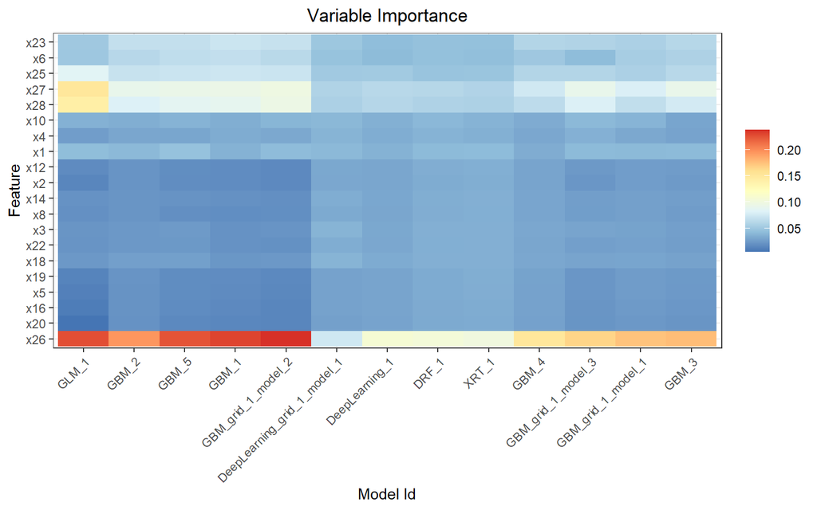

```r
varimp_heatmap <- h2o.varimp_heatmap(aml)
print(varimp_heatmap)
```

```r
# process
aml@training_info
```

```
## $creation_epoch
## [1] "1721311142"
##
## $start_epoch
## [1] "1721311142"
##
## $start_GLM_def_1
## [1] "1721311142"
##
## $start_GBM_def_5
## [1] "1721311144"
##
## $start_DRF_def_1
## [1] "1721311149"
##
## $start_GBM_def_2
## [1] "1721311160"
##
## $start_GBM_def_3
## [1] "1721311165"
##
## $start_GBM_def_4
## [1] "1721311169"
##
## $start_DRF_XRT
## [1] "1721311174"
##
## $start_GBM_def_1
## [1] "1721311186"
##
## $start_DeepLearning_def_1
## [1] "1721311190"
##
## $start_GBM_grid_1
## [1] "1721311192"
##
## $start_DeepLearning_grid_1
## [1] "1721311207"
##
## $start_DeepLearning_grid_2
## [1] "1721311404"
##
## $stop_epoch
## [1] "1721311443"
##
## $duration_secs
## [1] "301"
```

```r
aml@modeling_steps
```

```
## [[1]]
## [[1]]$name
## [1] "GLM"
##
## [[1]]$steps
## [[1]]$steps[[1]]
## [[1]]$steps[[1]]$id
## [1] "def_1"
##
## [[1]]$steps[[1]]$group
## [1] 1
##
## [[1]]$steps[[1]]$weight
## [1] 10
##
##
##
##
## [[2]]
## [[2]]$name
## [1] "GBM"
##
## [[2]]$steps
## [[2]]$steps[[1]]
## [[2]]$steps[[1]]$id
## [1] "def_5"
##
## [[2]]$steps[[1]]$group
## [1] 1
##
## [[2]]$steps[[1]]$weight
## [1] 10
##
##
##
##
## [[3]]
## [[3]]$name
## [1] "DRF"
##
```

[output cut: 136 more lines]

```
## [1] 4
##
## [[9]]$steps[[1]]$weight
## [1] 30
##
##
## [[9]]$steps[[2]]
## [[9]]$steps[[2]]$id
## [1] "grid_2"
##
## [[9]]$steps[[2]]$group
## [1] 5
##
## [[9]]$steps[[2]]$weight
## [1] 30
```

```r
m_1 <- aml@leader
GBM <- h2o.get_best_model(aml, algorithm = "GBM")
```

MSE: 0.09573392

RMSE: 0.309409

Log Loss: 0.3363902

Mean Per-Class Error: 0.09452053

AUC: 0.9701867

AUCPR: 0.9732027

Gini: 0.9403734

```r
h2o.api("GET /3/NetworkTest")
```

```
## $`__meta`
## $`__meta`$schema_version
## [1] 3
##
## $`__meta`$schema_name
## [1] "NetworkTestV3"
##
## $`__meta`$schema_type
## [1] "NetworkTest"
##
##
## $`_exclude_fields`
## [1] ""
##
## $microseconds_collective
## [1] 24.51  3.84  8.43
##
## $bandwidths_collective
## [1] 8.159935e+04 5.333333e+08 2.487725e+11
##
## $microseconds
##       [,1]
## [1,] 50.86
## [2,] 18.12
## [3,] 29.04
##
## $bandwidths
##              [,1]
## [1,] 3.932363e+04
## [2,] 1.130243e+08
## [3,] 7.221598e+10
##
## $nodes
## [1] "/192.168.1.19:54327"
##
## $table
## Network Test: Launched from /192.168.1.19:54327
##                     destination             1_bytes           1024_bytes
## 1 all - collective bcast/reduce  24 usec, 79.7 KB/S   3 usec, 508.6 MB/S
## 2      self /192.168.1.19:54327  50 usec, 38.4 KB/S  18 usec, 107.8 MB/S
##           1048576_bytes
## 1   8 usec, 231.69 GB/S
## 2   29 usec, 67.26 GB/S
```

```r
# all LB info
all_lb <- h2o.get_leaderboard(object = aml, extra_columns = "ALL")
all_lb
```

```
##                                      model_id       auc   logloss     aucpr
## 1              GBM_1_AutoML_15_20240718_85902 0.7823365 0.5576492 0.7998535
## 2              GBM_5_AutoML_15_20240718_85902 0.7799989 0.5609855 0.7974935
## 3 GBM_grid_1_AutoML_15_20240718_85902_model_2 0.7792186 0.5621636 0.7968146
## 4 GBM_grid_1_AutoML_15_20240718_85902_model_1 0.7781019 0.5620892 0.7950570
## 5              GBM_2_AutoML_15_20240718_85902 0.7759464 0.5636773 0.7969840
## 6              GBM_3_AutoML_15_20240718_85902 0.7751384 0.5646148 0.7959063
##   mean_per_class_error      rmse       mse training_time_ms
## 1            0.3322160 0.4352855 0.1894734              932
## 2            0.3177555 0.4365882 0.1906092              858
## 3            0.3163956 0.4370600 0.1910214              832
## 4            0.3418061 0.4374305 0.1913454             1065
## 5            0.3403384 0.4383222 0.1921264              876
## 6            0.3451342 0.4387778 0.1925259              807
##   predict_time_per_row_ms algo
## 1                0.002996  GBM
## 2                0.002415  GBM
## 3                0.002256  GBM
## 4                0.002227  GBM
## 5                0.002040  GBM
## 6                0.002537  GBM
##
## [13 rows x 10 columns]
```

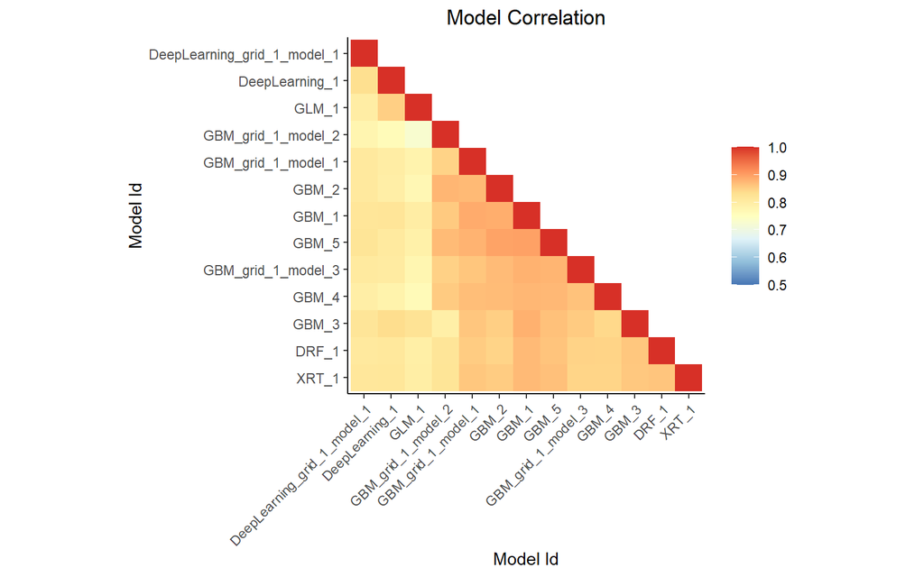

```r
#model correlations
mc_plot <- h2o.model_correlation_heatmap(aml, test)
mc_plot
```

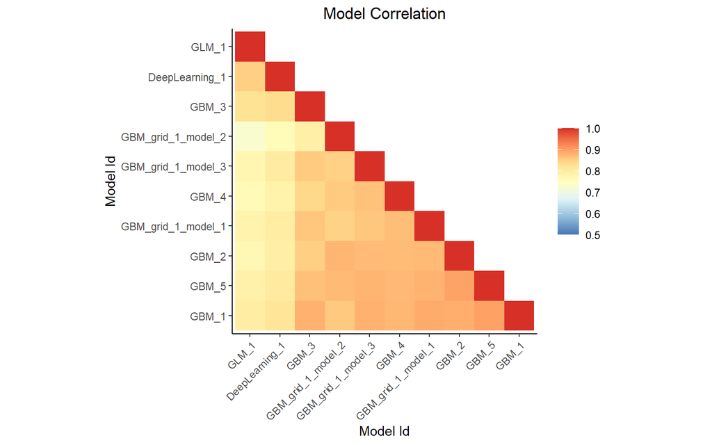

```r
# An extended leaderboard can be used
mc_plot <- h2o.model_correlation_heatmap(
  h2o.head(h2o.arrange(h2o.get_leaderboard(aml,
           extra_columns = "training_time_ms"),
            training_time_ms),
              n = 10),
               test)
mc_plot
```

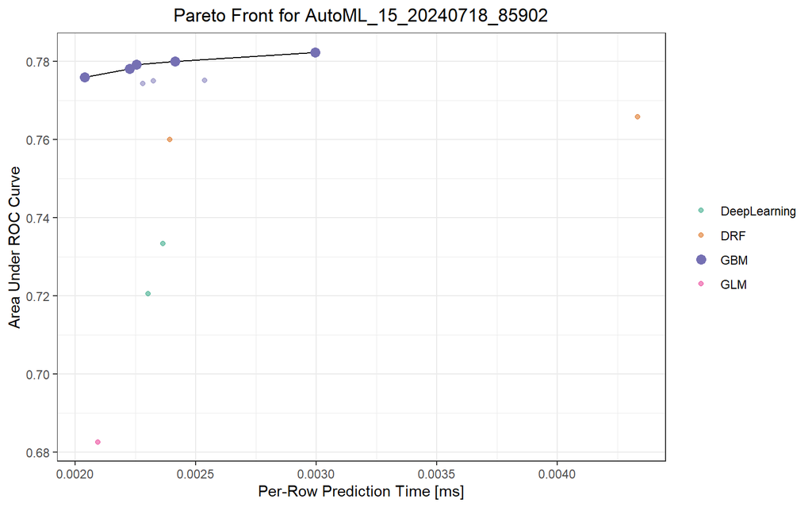

```r
# More complicated queries on leaderboard can be used, e.g., model correlation between 5 fastest models to train and Stacked Ensembles
leaderboard <- as.data.frame(h2o.arrange(
  h2o.get_leaderboard(aml, extra_columns = "training_time_ms"), training_time_ms))


mc_plot <- h2o.model_correlation_heatmap(
  rbind(head(leaderboard, n = 10),
  leaderboard[grep("StackedEnsemble",leaderboard$model_id),]), test)

# to retrieve the Pareto front subset of the leaderboard
pf <- h2o.pareto_front(aml)
plot(pf)
```

```r
pf@pareto_front
```

```
##                                      model_id       auc   logloss     aucpr
## 5              GBM_2_AutoML_15_20240718_85902 0.7759464 0.5636773 0.7969840
## 4 GBM_grid_1_AutoML_15_20240718_85902_model_1 0.7781019 0.5620892 0.7950570
## 3 GBM_grid_1_AutoML_15_20240718_85902_model_2 0.7792186 0.5621636 0.7968146
## 2              GBM_5_AutoML_15_20240718_85902 0.7799989 0.5609855 0.7974935
## 1              GBM_1_AutoML_15_20240718_85902 0.7823365 0.5576492 0.7998535
##   mean_per_class_error      rmse       mse training_time_ms
## 5            0.3403384 0.4383222 0.1921264              876
## 4            0.3418061 0.4374305 0.1913454             1065
## 3            0.3163956 0.4370600 0.1910214              832
## 2            0.3177555 0.4365882 0.1906092              858
## 1            0.3322160 0.4352855 0.1894734              932
##   predict_time_per_row_ms algo
## 5                0.002040  GBM
## 4                0.002227  GBM
## 3                0.002256  GBM
## 2                0.002415  GBM
## 1                0.002996  GBM
```

```r
# Create the explanation for whole H2OAutoML object
explain_all <- h2o.explain(aml, test)
print(explain_all)
```

[output not shown]

```
##
##
## Variable Importance
## ===================
##
## > The variable importance plot shows the relative importance of the most important variables in the model.
```

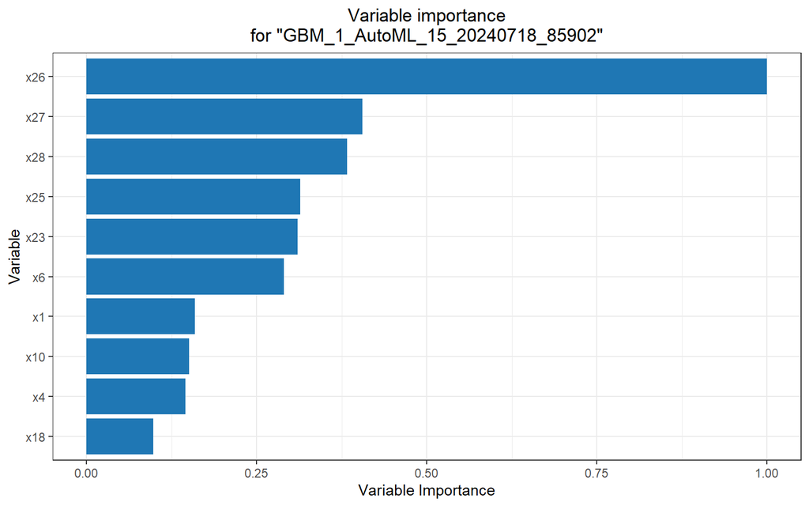

```
##
##
## Variable Importance Heatmap
## ===========================
##
## > Variable importance heatmap shows variable importance across multiple models. Some models in H2O return variable importance for one-hot (binary indicator) encoded versions of categorical columns (e.g. Deep Learning, XGBoost). In order for the variable importance of categorical columns to be com…
```

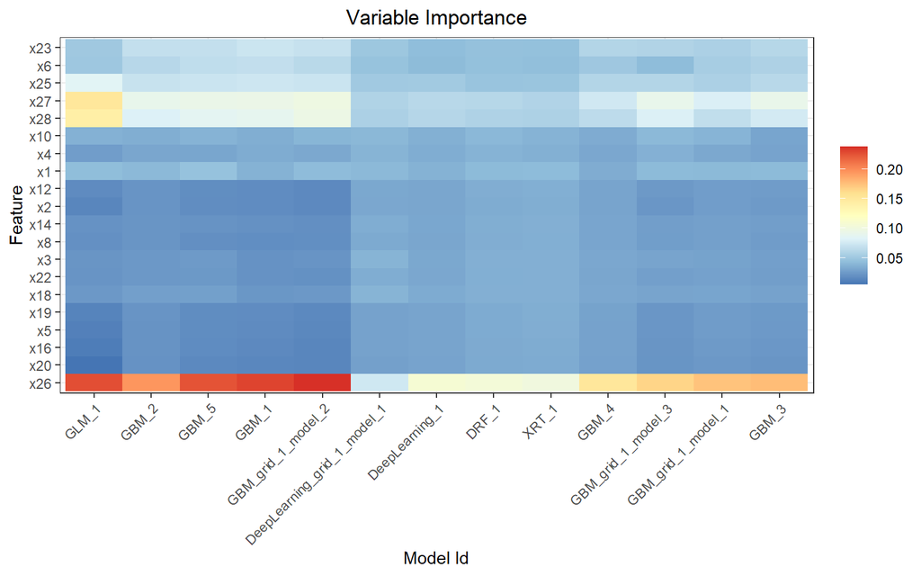

```
##
##
## Model Correlation
## =================
##
## > This plot shows the correlation between the predictions of the models. For classification, frequency of identical predictions is used. By default, models are ordered by their similarity (as computed by hierarchical clustering).
```

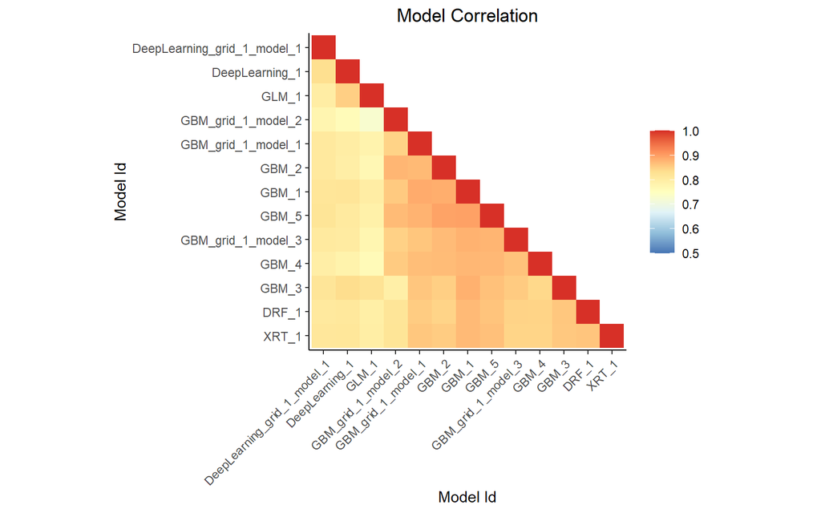

```
## Interpretable models: GLM_1_AutoML_15_20240718_85902
##
##
## SHAP Summary
## ============
##
## > SHAP summary plot shows the contribution of the features for each instance (row of data). The sum of the feature contributions and the bias term is equal to the raw prediction of the model, i.e., prediction before applying inverse link function.
```

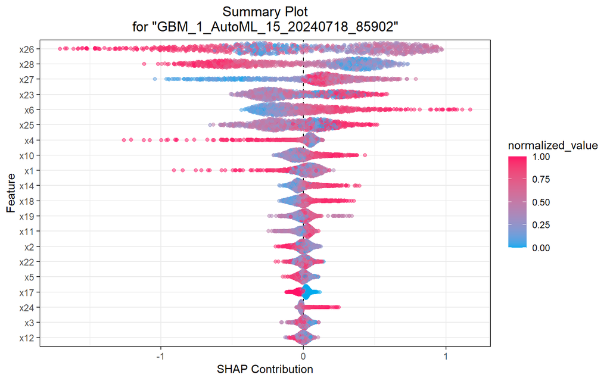

```
##
##
## Partial Dependence Plots
## ========================
##
## > Partial dependence plot (PDP) gives a graphical depiction of the marginal effect of a variable on the response. The effect of a variable is measured in change in the mean response. PDP assumes independence between the feature for which is the PDP computed and the rest.
```

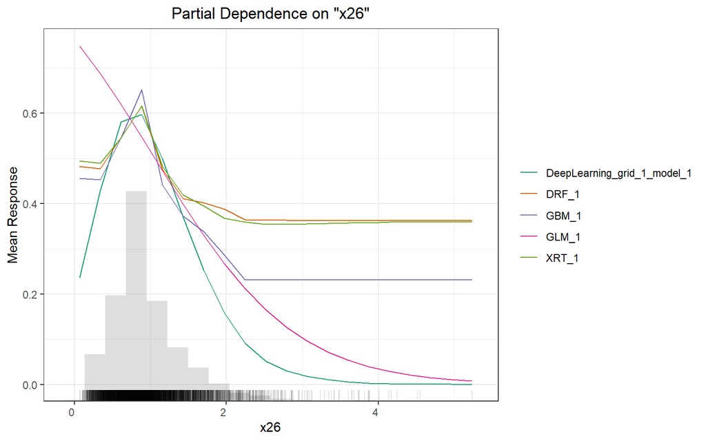

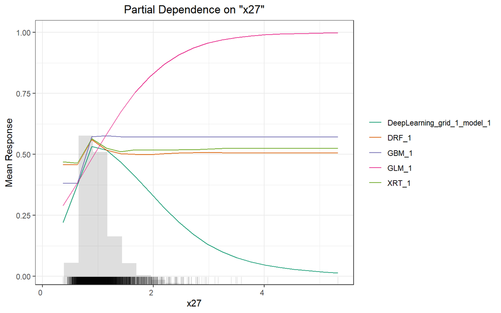

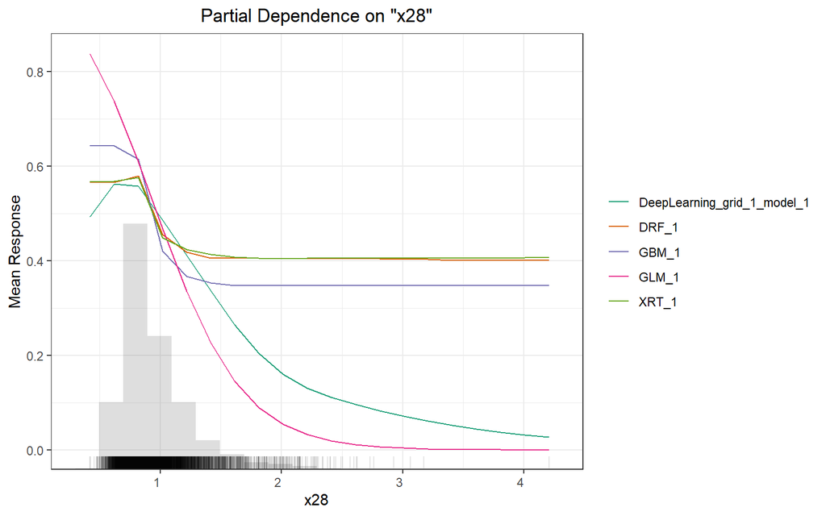

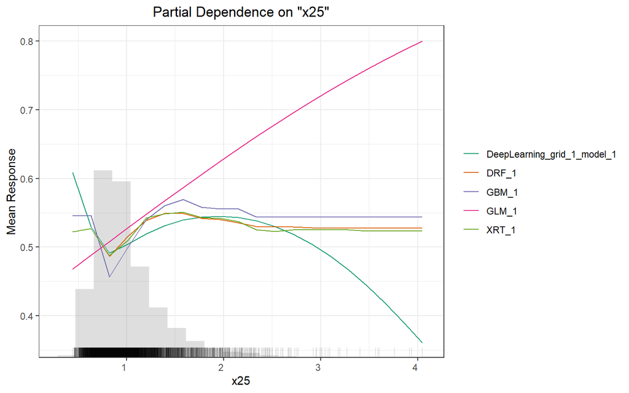

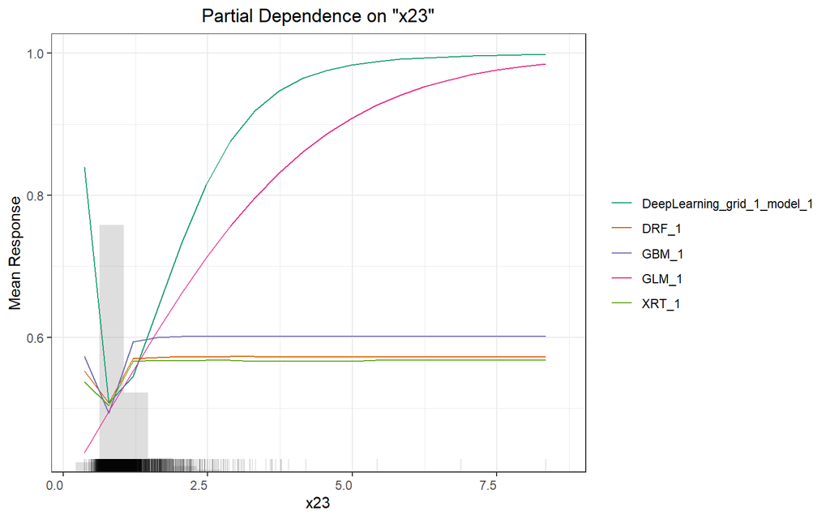

```r
# Create the explanation for the leader model
explain_1 <- h2o.explain(aml@leader, test)
print(explain_1)
```

```
##
##
## Confusion Matrix
## ================
##
## > Confusion matrix shows a predicted class vs an actual class.
##
##
##
## GBM_1_AutoML_15_20240718_85902
## ------------------------------
##
## |  | 0 | 1 | Error | Rate
## |:---:|:---:|:---:|:---:|:---:|
## | **0** |1047 | 1268 | 0.547732181425486 |  =1268/2315 |
## | **1** |276 | 2409 | 0.102793296089385 |  =276/2685 |
## | **Totals** |1323 | 3677 | 0.3088 |  =1544/5000 |
##
##
## Learning Curve Plot
## ===================
##
## > Learning curve plot shows the loss function/metric dependent on number of iterations or trees for tree-based algorithms. This plot can be useful for determining whether the model overfits.
```

```
##
##
## Variable Importance
## ===================
##
## > The variable importance plot shows the relative importance of the most important variables in the model.
```

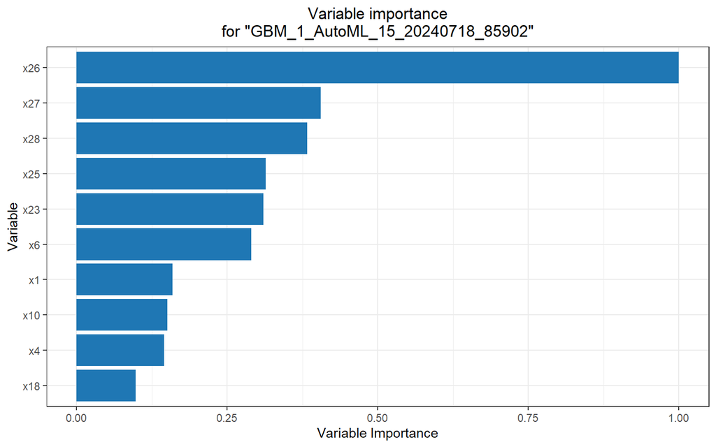

```
##
##
## SHAP Summary
## ============
##
## > SHAP summary plot shows the contribution of the features for each instance (row of data). The sum of the feature contributions and the bias term is equal to the raw prediction of the model, i.e., prediction before applying inverse link function.
```

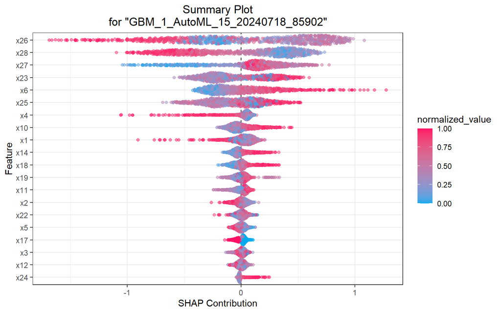

```
##
##
## Partial Dependence Plots
## ========================
##
## > Partial dependence plot (PDP) gives a graphical depiction of the marginal effect of a variable on the response. The effect of a variable is measured in change in the mean response. PDP assumes independence between the feature for which is the PDP computed and the rest.
```

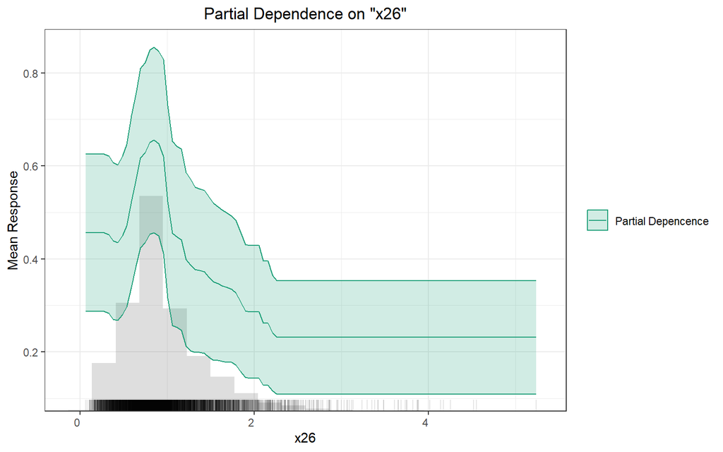

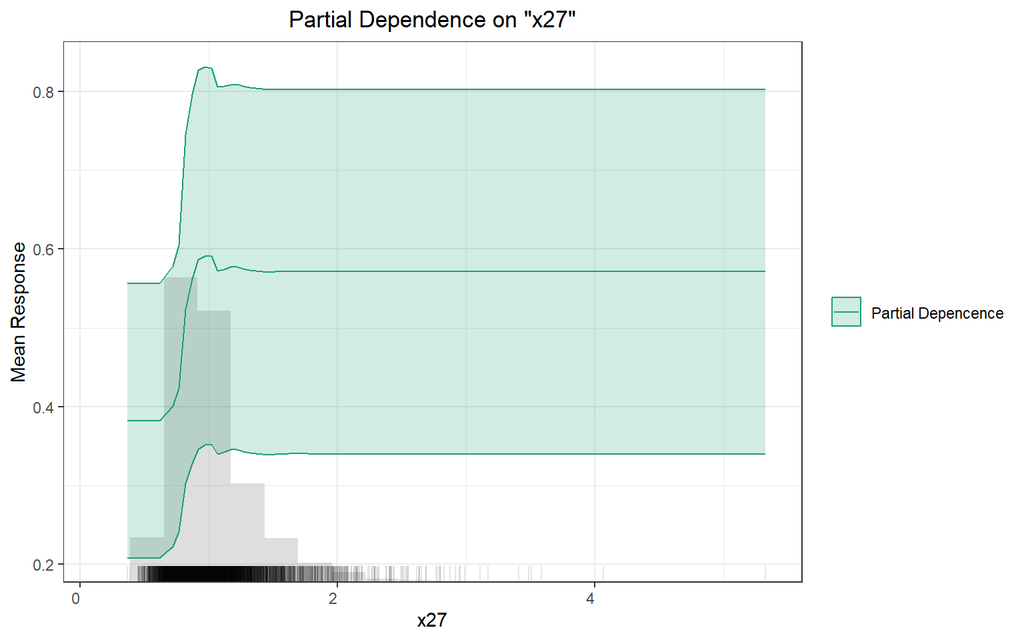

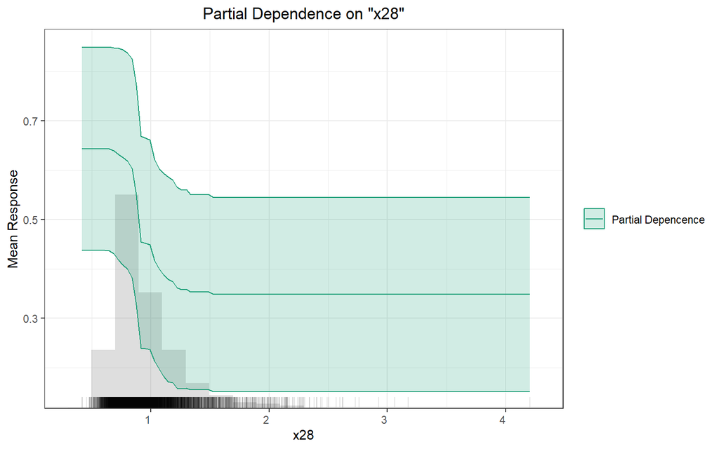

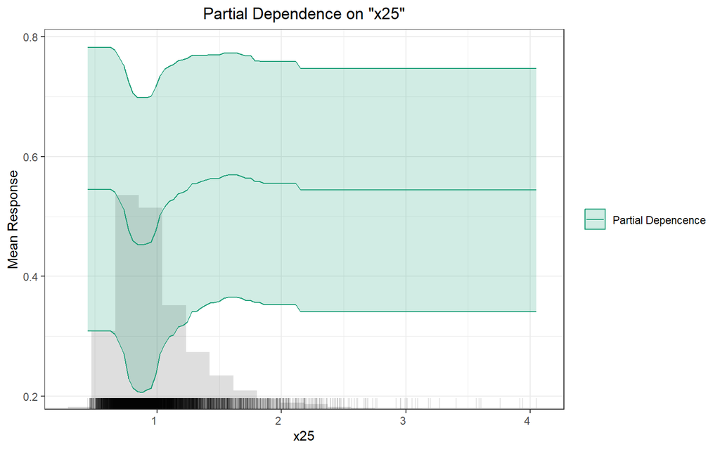

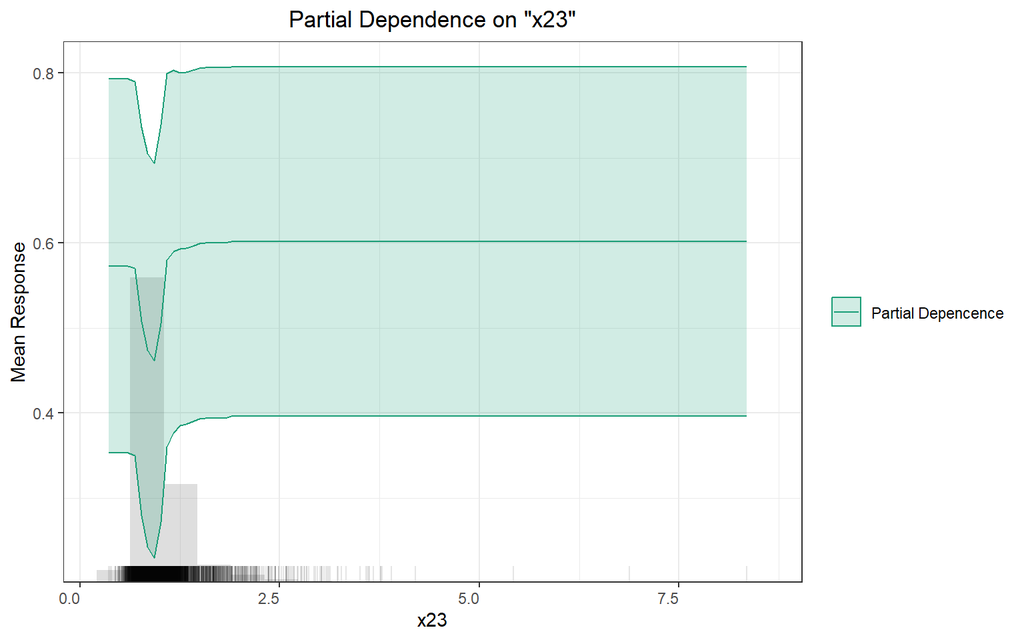

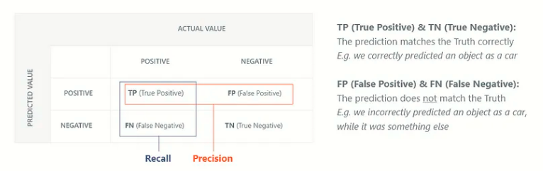

#### Learning Curve Plot

> Learning curve plot shows the loss function/metric dependent on number of iterations or trees for tree-based algorithms. This plot can be useful for determining whether the model overfits.

#### Variable Importance

> The variable importance plot shows the relative importance of the most important variables in the model.

#### SHAP Summary

> SHAP summary plot shows the contribution of the features for each instance (row of data). The sum of the feature contributions and the bias term is equal to the raw prediction of the model, i.e., prediction before applying inverse link function.

#### Partial Dependence Plots

> Partial dependence plot (PDP) gives a graphical depiction of the marginal effect of a variable on the response. The effect of a variable is measured in change in the mean response. PDP assumes independence between the feature for which is the PDP computed and the rest.

```r
learning_curve <- h2o.learning_curve_plot(m_1)
print(learning_curve)
```

[output not shown]

[figure not shown]

```r
shap_plot <- h2o.shap_summary_plot(GBM, test)
shap_plot
```

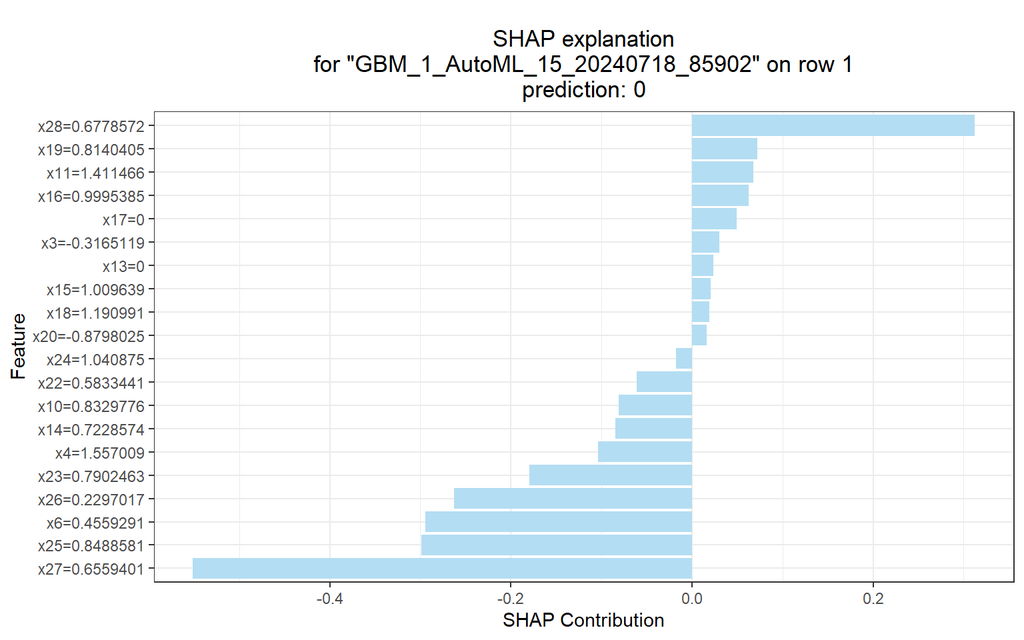

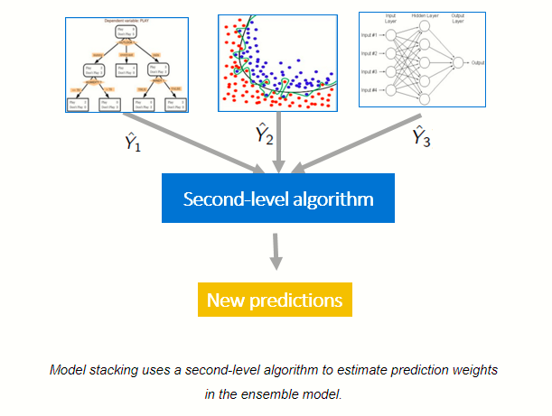

```r
shapr_plot <- h2o.shap_explain_row_plot(GBM, test, row_index = 1)
shapr_plot
```

Ensemble methods are commonly used to boost predictive accuracy by combining the predictions of multiple machine learning models. The traditional wisdom has been to combine so-called “weak” learners. However, a more modern approach is to create an ensemble of a well-chosen collection of strong yet diverse models.

Model stacking is an efficient ensemble method in which the predictions, generated by using various machine learning algorithms, are used as inputs in a second-layer learning algorithm. This second-layer algorithm is trained to optimally combine the model predictions to form a new set of predictions. For example, when linear regression is used as second-layer modeling, it estimates these weights by minimizing the least square errors. However, the second-layer modeling is not restricted to only linear models; the relationship between the predictors can be more complex, opening the door to employing other machine learning algorithms.

[figure not shown]

[figure not shown]

## **Agua**

The `agua` package provides tidymodels interface to the [H2O](https://h2o.ai/) platform and the [h2o](https://docs.h2o.ai/h2o/latest-stable/h2o-r/docs/index.html) R package. It has two main components

- new parsnip engine `'h2o'` for the following models:
  - [`linear_reg()`](https://parsnip.tidymodels.org/reference/linear_reg.html), [`logistic_reg()`](https://parsnip.tidymodels.org/reference/logistic_reg.html), [`poisson_reg()`](https://parsnip.tidymodels.org/reference/poisson_reg.html), [`multinom_reg()`](https://parsnip.tidymodels.org/reference/multinom_reg.html): All fit penalized generalized linear models. If the model parameters `penalty` and `mixture` are not specified, h2o will internally search for the optimal regularization settings.
  - [`boost_tree()`](https://parsnip.tidymodels.org/reference/boost_tree.html): . Fits boosted trees via xgboost. Use [`h2o::h2o.xgboost.available()`](https://rdrr.io/pkg/h2o/man/h2o.xgboost.available.html) to see if h2o’s xgboost is supported on your machine. For classical gradient boosting, use the `'h2o_gbm'` engine.
  - [`rand_forest()`](https://parsnip.tidymodels.org/reference/rand_forest.html): Random forest models.
  - [`naive_Bayes()`](https://parsnip.tidymodels.org/reference/naive_Bayes.html): Naive Bayes models.
  - [`rule_fit()`](https://parsnip.tidymodels.org/reference/rule_fit.html): RuleFit models.
  - [`mlp()`](https://parsnip.tidymodels.org/reference/mlp.html): Multi-layer feedforward neural networks.
  - [`auto_ml()`](https://parsnip.tidymodels.org/reference/auto_ml.html): Automatic machine learning.
- Infrastructure for the tune package, see [Tuning with agua](https://agua.tidymodels.org/articles/tune.html) for more details.

All supported models can accept an additional engine argument `validation`, which is a number between 0 and 1 specifying the *proportion* of data reserved as validation set. This can used by h2o for performance assessment and potential early stopping.

```r
library(tidymodels)
library(agua)
```

```r
library(ggplot2)

agua::h2o_running(verbose = TRUE)
```

```
## [1] TRUE
```

```r
 # Import a sample binary outcome train/test set into H2O
train <- h2o.importFile("https://s3.amazonaws.com/erin-data/higgs/higgs_train_10k.csv")
```

```
##   |                                                                              |                                                                      |   0%  |                                                                              |====================================                     …
```

```r
test <- h2o.importFile("https://s3.amazonaws.com/erin-data/higgs/higgs_test_5k.csv")
```

```
##   |                                                                              |                                                                      |   0%  |                                                                              |======================================================   …
```

```r
# Identify predictors and response
y <- "response"
x <- setdiff(names(train), y)

# For binary classification, response should be a factor
train[, y] <- as.factor(train[, y])
test[, y] <- as.factor(test[, y])


# run for a maximum of 120 seconds
auto_spec <-
  auto_ml() %>%
  set_engine("h2o", max_runtime_secs = 120, seed = 1) %>%
  set_mode("classification")

normalized_rec <-
  recipe(response ~ ., data = train) %>%
  step_normalize(all_predictors())

auto_wflow <-
  workflow() %>%
  add_model(auto_spec) %>%
  add_recipe(normalized_rec)


auto_fit <- fit(auto_wflow, data = as.data.frame(train))

extract_fit <- extract_fit_parsnip(auto_fit)

predict_auto_fit <- predict(auto_fit, new_data = as.data.frame(test))

metrics_results_auto_fit <- collect_metrics(auto_fit, summarize = TRUE)
```

### **Agua Results**

```r
extract_fit
```

```
## parsnip model object
##
## ═════════════════════════ H2O AutoML Summary: 29 models ════════════════════════
```

```
## Leader Algorithm: stackedensemble
```

```
## Leader ID: StackedEnsemble_AllModels_3_AutoML_16_20240718_91051
```

```
##
## ══════════════════════════════════ Leaderboard ═════════════════════════════════
##                                                  model_id       auc   logloss
## 1    StackedEnsemble_AllModels_3_AutoML_16_20240718_91051 0.7877578 0.5515525
## 2    StackedEnsemble_AllModels_2_AutoML_16_20240718_91051 0.7871104 0.5519990
## 3    StackedEnsemble_AllModels_4_AutoML_16_20240718_91051 0.7870484 0.5523828
## 4    StackedEnsemble_AllModels_1_AutoML_16_20240718_91051 0.7865090 0.5524395
## 5 StackedEnsemble_BestOfFamily_4_AutoML_16_20240718_91051 0.7832519 0.5556494
## 6 StackedEnsemble_BestOfFamily_3_AutoML_16_20240718_91051 0.7832077 0.5556340
##       aucpr mean_per_class_error      rmse       mse
## 1 0.8070076            0.3162000 0.4327597 0.1872809
## 2 0.8067871            0.3211479 0.4330350 0.1875193
## 3 0.8063877            0.3174868 0.4331195 0.1875925
## 4 0.8065080            0.3308342 0.4333097 0.1877573
## 5 0.8028277            0.3343056 0.4347709 0.1890257
## 6 0.8030530            0.3273714 0.4347580 0.1890145
```

```r
predict_auto_fit
```

```
## # A tibble: 5,000 × 1
##    .pred_class
##    <fct>
##  1 0
##  2 0
##  3 1
##  4 1
##  5 0
##  6 1
##  7 1
##  8 0
##  9 1
## 10 0
## # ℹ 4,990 more rows
```

```r
metrics_results_auto_fit
```

```
## # A tibble: 656 × 6
##    id                                    algorithm .metric    mean std_err     n
##    <chr>                                 <chr>     <chr>     <dbl>   <dbl> <int>
##  1 StackedEnsemble_AllModels_3_AutoML_1… stacking  accura… 6.90e-1 6.96e-3     5
##  2 StackedEnsemble_AllModels_3_AutoML_1… stacking  aic     2.24e+3 3.80e+1     5
##  3 StackedEnsemble_AllModels_3_AutoML_1… stacking  auc     7.88e-1 1.74e-3     5
##  4 StackedEnsemble_AllModels_3_AutoML_1… stacking  err     3.10e-1 6.96e-3     5
##  5 StackedEnsemble_AllModels_3_AutoML_1… stacking  err_co… 6.2 e+2 2.03e+1     5
##  6 StackedEnsemble_AllModels_3_AutoML_1… stacking  f0poin… 6.90e-1 7.50e-3     5
##  7 StackedEnsemble_AllModels_3_AutoML_1… stacking  f1      7.51e-1 2.97e-3     5
##  8 StackedEnsemble_AllModels_3_AutoML_1… stacking  f2      8.25e-1 7.17e-3     5
##  9 StackedEnsemble_AllModels_3_AutoML_1… stacking  lift_t… 1.87e+0 2.05e-2     5
## 10 StackedEnsemble_AllModels_3_AutoML_1… stacking  loglik… 0       0           5
## # ℹ 646 more rows
```

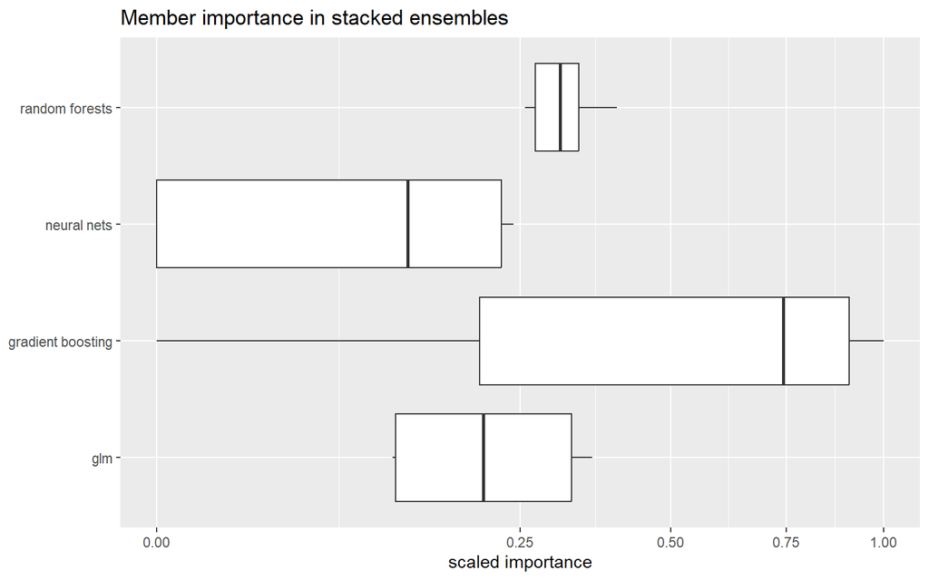

```r
auto_fit %>%
  extract_fit_parsnip() %>%
  member_weights() %>%
  unnest(importance) %>%
  filter(type == "scaled_importance") %>%
  ggplot() +
  geom_boxplot(aes(value, algorithm)) +
  scale_x_sqrt() +
  labs(y = NULL, x = "scaled importance", title = "Member importance in stacked ensembles")
```

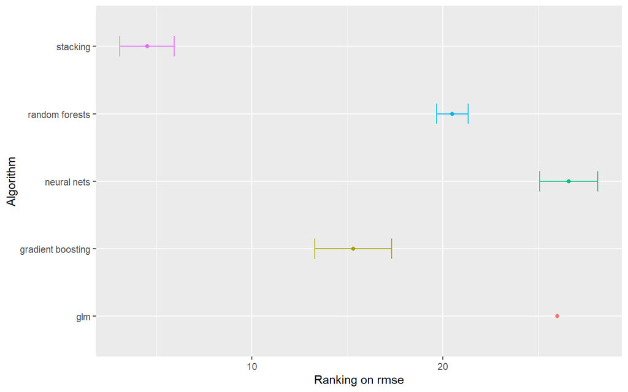

```r
autoplot(auto_fit, type = "rank", metric = c("mae", "rmse")) +
  theme(legend.position = "none")
```

## **Bonus: Create R, Tableau, and Data Connections**

**Step 1**

Install Rserve which is the package built to create R servers, and once installed load up the Rserve library and run Rserve or run.Rserve with your desired port.

- *install.packages(“Rserve”)*
- *library(Rserve)*
- *run.Rserve(port=6311)*

### **Metadata**

Tableau requires a data input of some sort in order to run but when dealing with immensely big data as a H2O user would typically do, it is impractical and unnecessarily time consuming to feed all the data into Tableau. So the solution is to create a small metadata file that can be easily loaded from disk. The metadata is just a file with factor levels of the data frame that’ll give a quick overview of the unique input values and cardinality of each column.

Set the workbook’s connection to the **Metadata_meta.csv** you created by navigating to the data section on the left sidebar, right clicking on the **Metadata_meta** and choosing to “Edit Connection.” Simply provide the location of the **Metadata_meta.csv** file and submit the new path.

- Configure the **IP_Address & Port** that H2O will launch at
- Set the path to the full **Metadata_meta** data file
- Fill in the parameters to creating the models you will implement
- Move a calculated field under Measures to the worksheet in order to execute the R script in the field:
  - Move *“01 Start H2O & Parse Data”* to the *Row* shelf which will trigger an execution.
  - Right click the field sitting on the *Row* shelf and select *Remove* to remove it from the worksheet.
  - Other calculated fields *“02 Execute Aggregation with H2O’s ddply”* and
  - *“03 Run Model”* to finish all the calculations necessary for the dashboard.